# Stock Price Time Series

-By Rohan Sharma

Table of Contents

#### Background

I have chosen to work on stock price data of TESLA. I was excited about the sharp rise in the stock price in the last couple of years. I have a desire to invest in stock in the future and this project will give me an idea how accurately i can independently predict stock prices and if i can base my investing decisions on my machine learning capabilities.

I have pulled the data using library quantmod. The data pulled is from 2010 till 2022, by default the quantmod library uses Yahoo as the source for these prices. The pulled data contains opening price, closing price, highest , lowest prices for each day. We will be using closing price of the stock as the target variable for this assignment.

In my opinion, predicting the stock price univariately would be very difficult, this is because a lot of external factors affect stock price as it reflects the the belief of people in the future profitability of a company. We have often seen tweets can also affect stock prices significantly.

```r
knitr::opts_chunk$set(warning=FALSE,
                      message=FALSE,
                      error=FALSE)
#Load libraries
library(dplyr)
library(janitor)
library(lubridate)
library(readr)
library(zoo)
library(quantmod)
```

```r
library(ggplot2)
library(tseries)
library(forecast)
univPlots <- function (x){
        # set up a matrix layout for multiple plots
        mat <- rbind(1:3, 4:6)
        layout(mat)
        # 1
        plot(x, main='Stock Price scatter')
        # 2
        hist(x, main="Stock Price - frequency")
        # 3
        boxplot(x, main='boxplot')
        # 5
        x.density <- density(x)
        plot(x.density, main="density plot")
        polygon(x.density, col="lightblue", border="black")


    #reset plot layout
    layout(c(1,1))
}
```

#### Data Pull

```r
getSymbols("TSLA")
```

```
## [1] "TSLA"
```

```r
dim(TSLA)
```

```
## [1] 2928    6
```

#### Line chart for Tesla Stock Prices

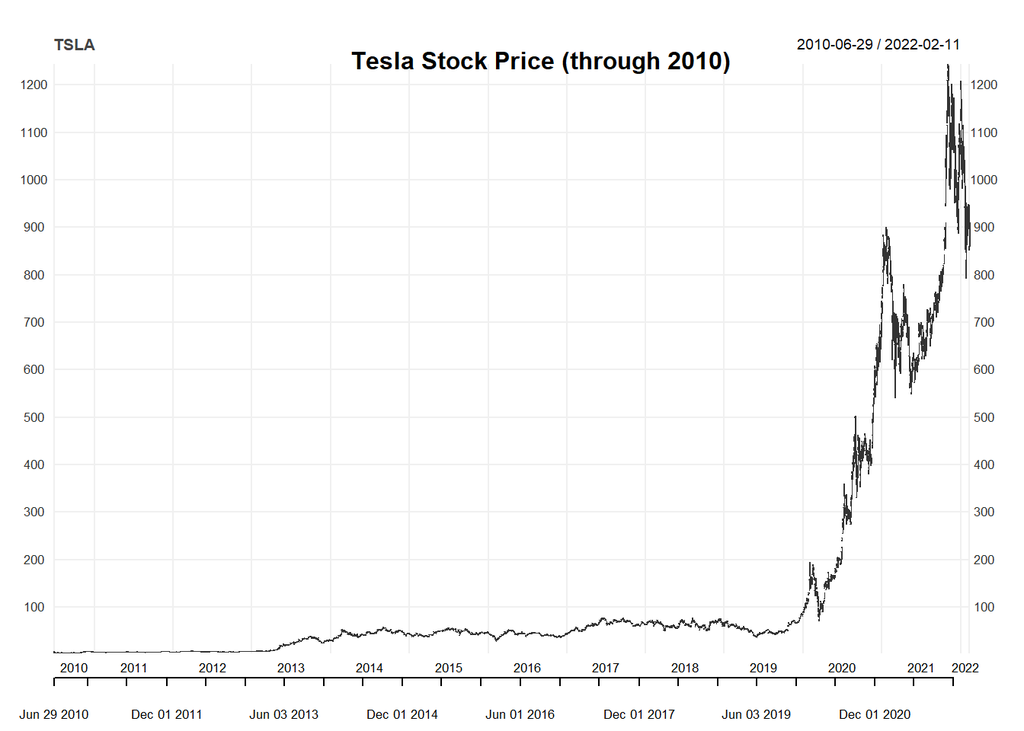

```r
chart_Series(TSLA)
title("Tesla Stock Price (through 2010)",  cex.main = 1,  font.main= 2, col.main= "BLACK")
```

From the above graph, we see that the stock prices are below 100 from 2010 to 2019. However, the prices shoot up from 2020 significantly.

##### Line Chart for Tesla Stock Prices - 2019 till Date

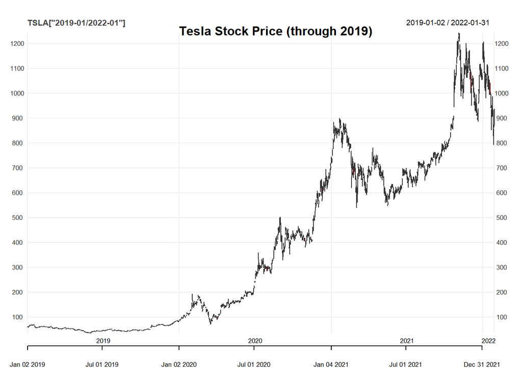

```r
chart_Series(TSLA['2019-01/2022-01'])
  title("Tesla Stock Price (through 2019)",  cex.main = 1,  font.main= 2, col.main= "BLACK")
```

##### Check for Null Values

```r
colSums(is.na(TSLA))
```

```
##     TSLA.Open     TSLA.High      TSLA.Low    TSLA.Close   TSLA.Volume
##             0             0             0             0             0
## TSLA.Adjusted
##             0
```

```r
tesla <-data.frame(date=index(TSLA), coredata(TSLA))
str(tesla[])
```

```
## 'data.frame':    2928 obs. of  7 variables:
##  $ date         : Date, format: "2010-06-29" "2010-06-30" ...
##  $ TSLA.Open    : num  3.8 5.16 5 4.6 4 ...
##  $ TSLA.High    : num  5 6.08 5.18 4.62 4 ...
##  $ TSLA.Low     : num  3.51 4.66 4.05 3.74 3.17 ...
##  $ TSLA.Close   : num  4.78 4.77 4.39 3.84 3.22 ...
##  $ TSLA.Volume  : num  93831500 85935500 41094000 25699000 34334500 ...
##  $ TSLA.Adjusted: num  4.78 4.77 4.39 3.84 3.22 ...
```

##### Subsetting data to have only closing price for analysis

```r
tesla<-tesla %>%
  select(date ,TSLA.Close)
names(tesla)[2] <- 'closing_price'

str(tesla[])
```

```
## 'data.frame':    2928 obs. of  2 variables:
##  $ date         : Date, format: "2010-06-29" "2010-06-30" ...
##  $ closing_price: num  4.78 4.77 4.39 3.84 3.22 ...
```

Since we are interested in the closing price of the stocks we filter the Closing price and date columns from the dataset.

##### Missing Dates

```r
date_range <- seq(min(tesla$date), max(tesla$date), by = 1)
missing_dates<-date_range[!date_range %in% tesla$date]
str(missing_dates)
```

```
##  Date[1:1318], format: "2010-07-03" "2010-07-04" "2010-07-05" "2010-07-10" "2010-07-11" ...
```

**We observe that weekend dates are missing, we need to keep this in mind when forecasting**

```r
missing_dates_df <-data.frame(missing_dates)

max(missing_dates_df$missing_dates)
```

```
## [1] "2022-02-06"
```

We check for the missing dates in the dataset to see if we have continuous data. We find that the data is available from 2010 to 2022 for weekdays, i.e. monday through friday.

#### Univariate charts to understand the disteribution of stock price in the last 12 years

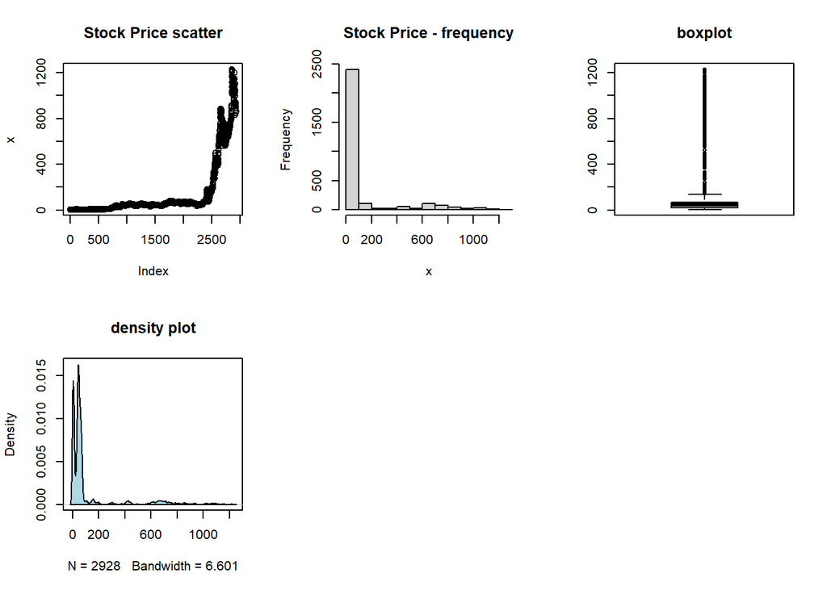

```r
univPlots(tesla$closing_price)
```

**Stock-Price Scatter** - This graph aligns with the line graph shown above. The prices are low and pretty much constant from 2010 to 2019 with little fluctuation, while the values hike up after 2019.

**Stock Price- frequency** - This graph shows the frequency of prices. We see that for most of the days the Tesla stock prices lie in the range of 0-100. Since for nearly 10 years of data we collected, the prices are low, hence maximum records fall in this category.

**Boxplot** - This graph shows the distribution of the stock prices, highlighting the outliers.

**Density Plot** - Density plot corroborates with the finding from the frequency plot - Most of the days the stock prices lied in between 0-100.

**Density dot plot of the closing price shows how data is highly skewed**

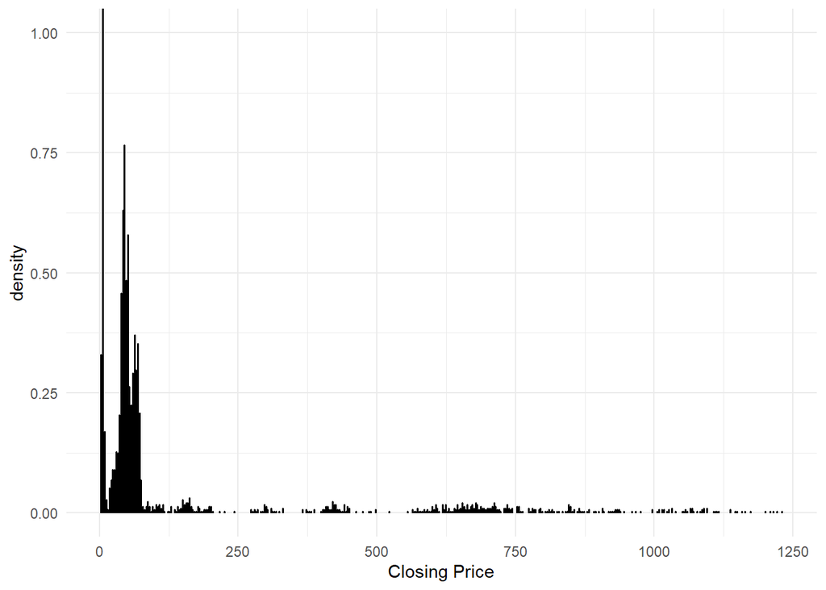

```r
ggplot(tesla, aes(x = as.numeric(closing_price), y=..density..))+
  geom_dotplot(binwidth = 3,method = 'histodot') +
  labs(x = 'Closing Price') +
  theme_minimal()
```

##### Plot showing the increase in stock price of TESLA stock

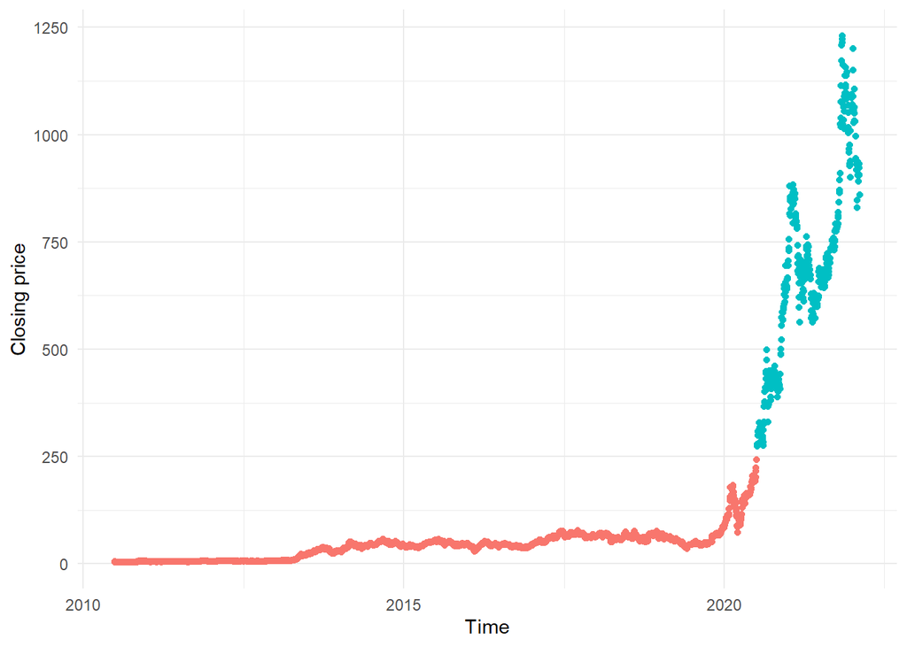

```r
ggplot(tesla, aes(x=date, y= as.numeric(closing_price), color = (closing_price >= 250))) +
  geom_point(show.legend = FALSE) +
  labs(x = 'Time', y='Closing price') +
  theme_minimal()
```

**Summary Statistics**

```r
summary(tesla$closing_price)
```

```
##    Min. 1st Qu.  Median    Mean 3rd Qu.    Max.
##    3.16   18.81   46.33  131.83   67.31 1229.91
```

We see a range of ~1225 in the stock price of Tesla. If we invested $100,000 @ $3.16 per share, we could have cashed out with $38,921,202 at the all time high.

**Linear Model**

```r
attach(tesla)
model <- lm(closing_price ~ date)
summary(model)
```

```
##
## Call:
## lm(formula = closing_price ~ date)
##
## Residuals:
##     Min      1Q  Median      3Q     Max
## -248.23 -124.25  -13.70   75.76  837.65
##
## Coefficients:
##               Estimate Std. Error t value Pr(>|t|)
## (Intercept) -2.045e+03  4.648e+01  -44.01   <2e-16 ***
## date         1.287e-01  2.741e-03   46.97   <2e-16 ***
## ---
## Signif. codes:  0 '***' 0.001 '**' 0.01 '*' 0.05 '.' 0.1 ' ' 1
##
## Residual standard error: 182 on 2926 degrees of freedom
## Multiple R-squared:  0.4298, Adjusted R-squared:  0.4296
## F-statistic:  2206 on 1 and 2926 DF,  p-value: < 2.2e-16
```

**Checking autocorrelation and stationarity in the data - and increasing the stationarity to better predict the data generation process**

#### Stationarity Check

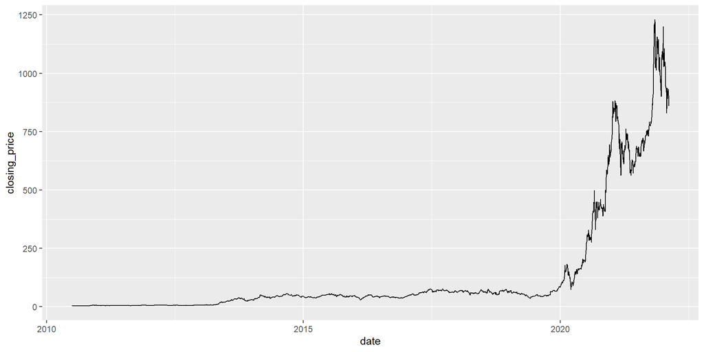

```r
library(ggplot2)

ggplot(tesla, aes(x = date, y = closing_price)) +
       geom_line()
```

##### ADF Test

We used the ADF test to check if the data is stationary Null Hypothesis: The data in *non stationary*

```r
##using library tseries
adf.test(tesla$closing_price)
```

```
##
##  Augmented Dickey-Fuller Test
##
## data:  tesla$closing_price
## Dickey-Fuller = -0.59281, Lag order = 14, p-value = 0.9776
## alternative hypothesis: stationary
```

The observed p value is very high, hence we fail to reject the null hypothesis. The data is non-stationary. To confirm our findings we recheck using the KPSS Test

##### KPSS Test**

We used the KPSS test to recheck if the data is stationary Null Hypothesis: The data in *stationary*

```r
kpss.test(tesla$closing_price)
```

```
##
##  KPSS Test for Level Stationarity
##
## data:  tesla$closing_price
## KPSS Level = 13.235, Truncation lag parameter = 9, p-value = 0.01
```

The observed p value is very low (<0.05), hence we reject the null hypothesis. The data is non-stationary.

#### Transformations

As the data is non-stationary, we perform transformations to get Constant Variance in the target variable.

Log Transformation

##### Log Transformation of Closing Price

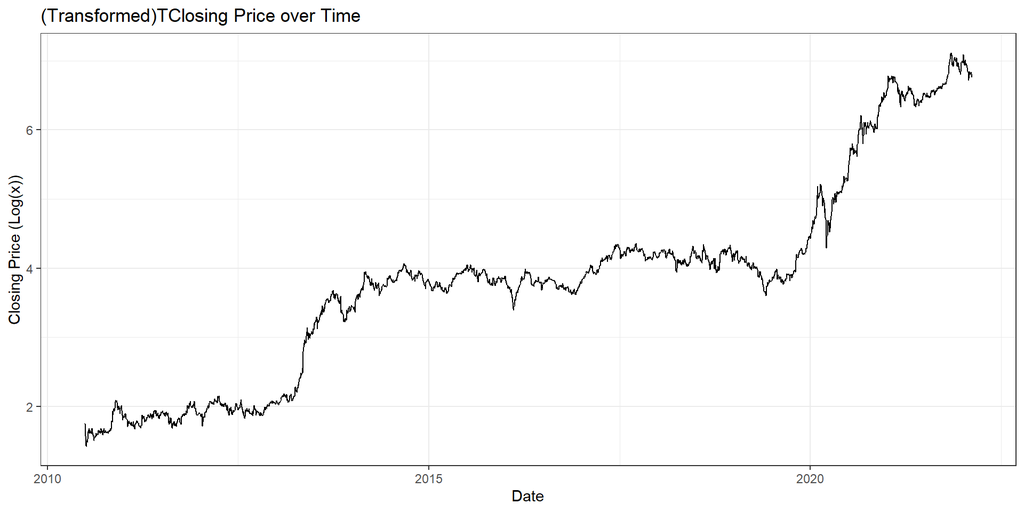

```r
tesla = tesla %>%
  mutate(closing_price_log = log1p(closing_price))

tesla %>%
  ggplot() +
      geom_line(aes(date,closing_price_log)) +
      theme_bw() +
      ggtitle("(Transformed)TClosing Price over Time ") +
      ylab("Closing Price (Log(x))") +
      xlab("Date")
```

```r
##using library tseries
adf.test(tesla$closing_price_log)
```

```
##
##  Augmented Dickey-Fuller Test
##
## data:  tesla$closing_price_log
## Dickey-Fuller = -1.509, Lag order = 14, p-value = 0.7862
## alternative hypothesis: stationary
```

```r
kpss.test(tesla$closing_price_log)
```

```
##
##  KPSS Test for Level Stationarity
##
## data:  tesla$closing_price_log
## KPSS Level = 23.797, Truncation lag parameter = 9, p-value = 0.01
```

**The data is still Non-Stationary**

#### Differencing to achieve constant mean

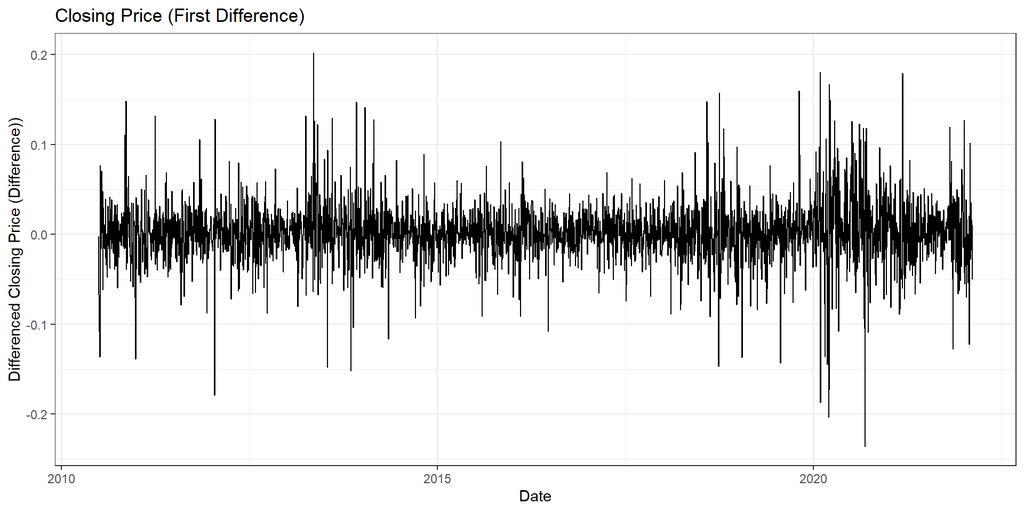

```r
tesla_final = tesla %>%
  mutate(closing_price_diff_log = closing_price_log - lag(closing_price_log))

tesla_final%>%
  ggplot() +
      geom_line(aes(date,closing_price_diff_log)) +
      theme_bw() +
      ggtitle("Closing Price (First Difference)") +
      ylab("Differenced Closing Price (Difference))") +
      xlab("Date")
```

*Wow! The differenced data looks perfectly mean reverting even though the variance seems fluctuating but still not much*

##### Re-checking stationarity with the tests

*Before testing we must remove the Na’s caused due to differencing (one row will have Na in our case as we differenced the data once)

```r
tesla_final <- na.omit(tesla_final)
```

```r
adf.test(tesla_final$closing_price_diff_log)
```

```
##
##  Augmented Dickey-Fuller Test
##
## data:  tesla_final$closing_price_diff_log
## Dickey-Fuller = -13.021, Lag order = 14, p-value = 0.01
## alternative hypothesis: stationary
```

```r
kpss.test(tesla_final$closing_price_diff_log)
```

```
##
##  KPSS Test for Level Stationarity
##
## data:  tesla_final$closing_price_diff_log
## KPSS Level = 0.16012, Truncation lag parameter = 9, p-value = 0.1
```

*The data is now stationary*

**We look at the ACF and PACF of the differenced data to estimate the data generating process**

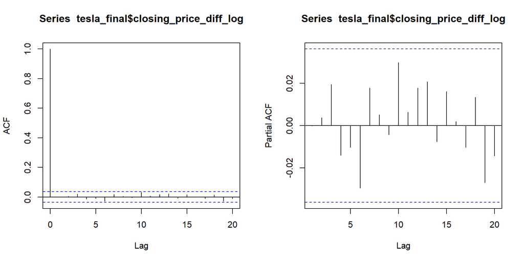

```r
par(mfrow = c(1,2))
acf(tesla_final$closing_price_diff_log,lag.max=20)
pacf(tesla_final$closing_price_diff_log,lag.max=20)
```

*The stock prices are usually a *random walk*, hence it is very tough to estimate the data generation process with ARIMA. We still try to model it using ARIMA to recheck*

```r
arima(tesla_final$closing_price_diff_log,order=c(1,0,1),include.mean = FALSE)
```

```
##
## Call:
## arima(x = tesla_final$closing_price_diff_log, order = c(1, 0, 1), include.mean = FALSE)
##
## Coefficients:
##          ar1     ma1
##       0.0014  0.0012
## s.e.     NaN     NaN
##
## sigma^2 estimated as 0.001135:  log likelihood = 5770.43,  aic = -11534.85
```

```r
arima(tesla_final$closing_price_diff_log,order=c(2,0,1),include.mean = FALSE)
```

```
##
## Call:
## arima(x = tesla_final$closing_price_diff_log, order = c(2, 0, 1), include.mean = FALSE)
##
## Coefficients:
##          ar1     ar2      ma1
##       0.6669  0.0062  -0.6645
## s.e.     NaN  0.0179      NaN
##
## sigma^2 estimated as 0.001135:  log likelihood = 5770.59,  aic = -11533.18
```

```r
arima(tesla_final$closing_price_diff_log,order=c(1,0,2),include.mean = FALSE)
```

```
##
## Call:
## arima(x = tesla_final$closing_price_diff_log, order = c(1, 0, 2), include.mean = FALSE)
##
## Coefficients:
##          ar1    ma1     ma2
##       0.0016  7e-04  0.0065
## s.e.     NaN    NaN     NaN
##
## sigma^2 estimated as 0.001135:  log likelihood = 5770.49,  aic = -11532.97
```

```r
arima(tesla_final$closing_price_diff_log,order=c(5,1,2),include.mean = FALSE)
```

```
##
## Call:
## arima(x = tesla_final$closing_price_diff_log, order = c(5, 1, 2), include.mean = FALSE)
##
## Coefficients:
##           ar1     ar2     ar3     ar4      ar5      ma1      ma2
##       -0.8318  0.0045  0.0233  0.0029  -0.0077  -0.1677  -0.8323
## s.e.      NaN  0.0241  0.0240  0.0220      NaN      NaN      NaN
##
## sigma^2 estimated as 0.001132:  log likelihood = 5768.66,  aic = -11521.32
```

```r
# Run auto ARIMA on the non-differenced data
auto_arima = auto.arima(tesla_final$closing_price)

auto_arima
```

```
## Series: tesla_final$closing_price
## ARIMA(2,1,2) with drift
##
## Coefficients:
##           ar1      ar2     ma1     ma2   drift
##       -1.0537  -0.9655  1.0826  0.9656  0.2793
## s.e.   0.0326   0.0208  0.0311  0.0317  0.1985
##
## sigma^2 = 113.3:  log likelihood = -11070.17
## AIC=22152.33   AICc=22152.36   BIC=22188.22
```

#### Auto ARIMA on the differenced data

```r
# Run auto ARIMA on the differenced data
auto_arima = auto.arima(tesla_final$closing_price_diff_log)

auto_arima
```

```
## Series: tesla_final$closing_price_diff_log
## ARIMA(2,0,2) with non-zero mean
##
## Coefficients:
##          ar1      ar2      ma1     ma2    mean
##       1.7365  -0.9515  -1.7330  0.9422  0.0017
## s.e.  0.2476   0.1679   0.2873  0.2073  0.0006
##
## sigma^2 = 0.001132:  log likelihood = 5777.05
## AIC=-11542.1   AICc=-11542.07   BIC=-11506.21
```

##### Run auto ARIMA on the non-differenced data

```r
auto_arima = auto.arima(tesla_final$closing_price_log,max.p = 7, max.q=7,max.order = 15)

auto_arima
```

```
## Series: tesla_final$closing_price_log
## ARIMA(4,1,3) with drift
##
## Coefficients:
##           ar1      ar2     ar3     ar4     ma1     ma2      ma3   drift
##       -0.0631  -0.7074  0.1872  0.0081  0.0629  0.7115  -0.1697  0.0017
## s.e.   0.9541   0.2027  0.6684  0.0323  0.9539  0.2117   0.6659  0.0006
##
## sigma^2 = 0.001135:  log likelihood = 5772.75
## AIC=-11527.5   AICc=-11527.43   BIC=-11473.66
```

#### Checking Auto-correlation in the residuals

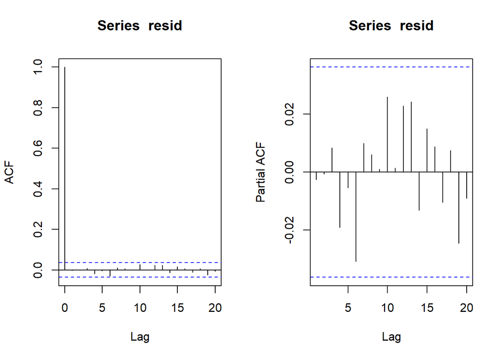

```r
best_mod = arima(tesla_final$closing_price_log,order=c(4,1,3))



par(mfrow=c(1,2))
resid = best_mod$resid
acf(resid,lag.max=20)
pacf(resid,lag.max=20)
```

*We see that there is no auto correlation in the residuals!*

##### Ljung-Box test

**Null Hypothesis: The time series is independent with no correlation**

```r
Box.test(resid,type='Ljung-Box',lag=1)
```

```
##
##  Box-Ljung test
##
## data:  resid
## X-squared = 0.019598, df = 1, p-value = 0.8887
```

```r
Box.test(resid,type='Ljung-Box',lag=5)
```

```
##
##  Box-Ljung test
##
## data:  resid
## X-squared = 1.3754, df = 5, p-value = 0.927
```

```r
Box.test(resid,type='Ljung-Box',lag=15)
```

```
##
##  Box-Ljung test
##
## data:  resid
## X-squared = 11.291, df = 15, p-value = 0.7317
```

**We fail to reject the null hypothesis, hence we there could be no correlation.**

```r
tesla_final$resid = best_mod$residuals
tesla_final$resid_invtransform=exp(tesla_final$resid)-1
tesla_final$closingprice_invtransform=exp(tesla_final$closing_price_log)-1
```

```r
head(tesla_final)
```

```
##         date closing_price closing_price_log closing_price_diff_log
## 2 2010-06-30         4.766          1.751979           -0.002079003
## 3 2010-07-01         4.392          1.684916           -0.067062226
## 4 2010-07-02         3.840          1.576915           -0.108001653
## 5 2010-07-06         3.222          1.440309           -0.136605771
## 6 2010-07-07         3.160          1.425515           -0.014793875
## 7 2010-07-08         3.492          1.502298            0.076782963
##          resid resid_invtransform closingprice_invtransform
## 2  0.001751978        0.001753513                     4.766
## 3 -0.066889767       -0.064701704                     4.392
## 4 -0.107558525       -0.101976036                     3.840
## 5 -0.135720919       -0.126913740                     3.222
## 6 -0.013227000       -0.013139907                     3.160
## 7  0.078780111        0.081966383                     3.492
```

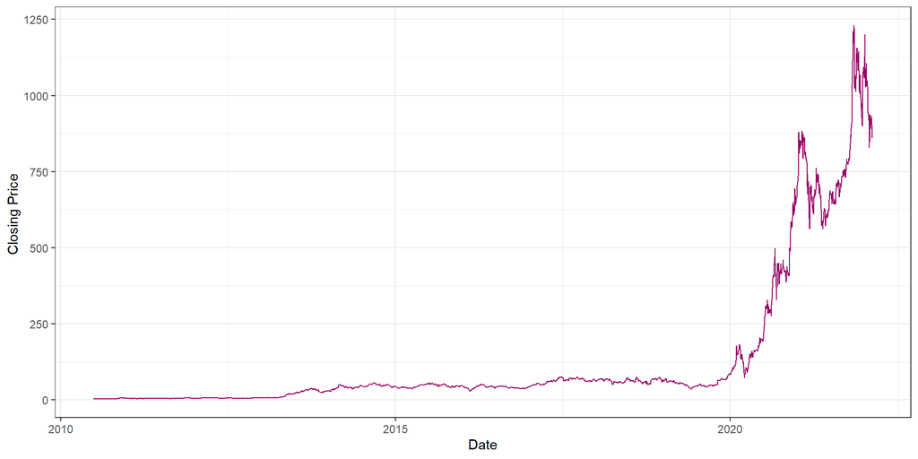

```r
tesla_final$pred =  tesla_final$closing_price -  tesla_final$resid_invtransform

ggplot()+
  geom_line(aes(tesla_final$date,tesla_final$closing_price),color='red')+
  geom_line(aes(tesla_final$date,tesla_final$pred),color='blue',alpha=0.4)+
  theme_bw()+
  xlab("Date")+
  ylab("Closing Price ")
```

```r
RMSE = sqrt(mean((tesla_final$pred - tesla_final$closing_price)^2,na.rm=T))
RMSE
```

```
## [1] 0.03381455
```

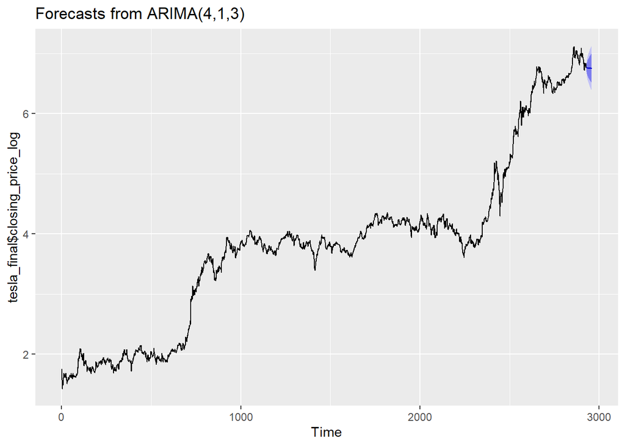

```r
  best_mod %>%
  forecast(h=30)  %>%
autoplot()
```

#### Inverse Transform The forecasts are in log transformed values we inverse them to attain real stock price values

```r
 forecast= best_mod %>%
  forecast(h=30)
```

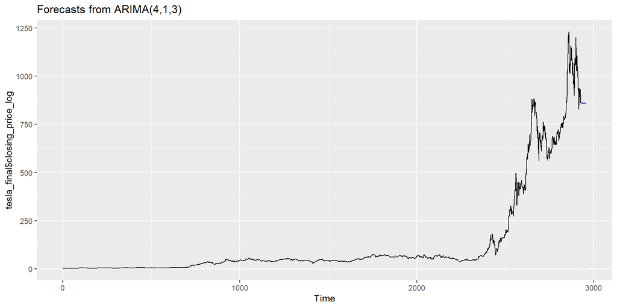

```r
forecast$mean=exp(forecast$mean)-1
forecast$fitted=exp(forecast$fitted)-1
forecast$x=exp(forecast$x)-1


autoplot(forecast)
```

(please ignore the Y axis label - it is actual stock price and not the log transformation)

**We have derived the forecasted closing price for the next 30 days!**